# Who Gets Power First? A Classification Model

## Part 6: The Ethics of Misclassification

Every classification error in this model has a human consequence. This section asks you to think carefully about what those consequences are — and who bears them.

This is not a coding exercise. It is the most important part of the notebook.

```python
# Scenario: Your smart city experiences a major hurricane.
# Grid capacity is reduced to 40% of normal for 72 hours.
# Your classification model is directing power allocation automatically.

# Calculate approximate power demand by tier
critical_mean   = df[df['priority_tier'] == 'Critical']['global_mean_kWh'].mean()
flexible_mean   = df[df['priority_tier'] == 'Flexible']['global_mean_kWh'].mean()
noncrit_mean    = df[df['priority_tier'] == 'Non_Critical']['global_mean_kWh'].mean()

n_critical   = len([b for b, t in priority_labels.items() if t == 'Critical'])
n_flexible   = len([b for b, t in priority_labels.items() if t == 'Flexible'])
n_noncrit    = len([b for b, t in priority_labels.items() if t == 'Non_Critical'])

total_critical = critical_mean * n_critical
total_flexible = flexible_mean * n_flexible
total_all      = df['global_mean_kWh'].mean() * 19

print("Hurricane Scenario — Power Budget Analysis")
print("=" * 50)
print(f"Total normal grid demand:     {total_all:.0f} kWh")
print(f"Available at 40% capacity:    {total_all * 0.4:.0f} kWh")
print(f"")
print(f"Critical tier demand ({n_critical} buildings):   {total_critical:.0f} kWh")
print(f"Critical as % of available:   {total_critical/(total_all*0.4)*100:.1f}%")
print(f"")
print(f"Critical + Flexible demand:   {total_critical + total_flexible:.0f} kWh")
print(f"As % of available:            {(total_critical+total_flexible)/(total_all*0.4)*100:.1f}%")
```

```
Hurricane Scenario — Power Budget Analysis
==================================================
Total normal grid demand:     1412 kWh
Available at 40% capacity:    565 kWh

Critical tier demand (5 buildings):   589 kWh
Critical as % of available:   104.2%

Critical + Flexible demand:   718 kWh
As % of available:            127.2%
```

```python
# Exercise 6.1 — The hardest questions
# Answer all five. These belong in your Week 4 design proposal.

# Q1: Based on the power budget analysis above —
#     can your Critical tier be fully powered at 40% grid capacity?
#     If not, what does that mean for your classification system?
#     Do you need to add a fourth tier? Reduce Critical tier size?
# A: The critical tier could not be fully powered, it would be just over the avialable power. The classification system would fail. I think it would be best to limit the power of some critical tiers,
#   for example, a grocery store would not need to have all its lights on and many other ways they could limit thier power.

# Q2: Your model misclassified 1 building.
#     For EACH misclassified building, describe the real-world consequence
#     of that error during the 72-hour hurricane scenario.
#     Be specific — who is affected and how?
# A: People in need of gasoline are effected, gas stations would not have the nessacary power and would not be able to get those in need gas.

# Q3: Your model learned priority tiers from labels YOUR TEAM assigned.
#     If a different team assigned different labels, they would get
#     a different model with different errors.
#     What does this tell you about the relationship between human decisions
#     and AI outputs? Who is responsible for the model's errors?
# A: People are responsible for a model's errors. The models are made and decieded fully based on human input, so they are directly responsible for how it performs.

# Q4: During the hurricane, a grocery store is classified as Non_Critical
#     and loses power. Emergency responders needed that store for food supplies.
#     Was this the model's fault? The labeler's fault? The system designer's fault?
#     What would you change?
# A: This would be the system designers fault. Their system in the one that failed and caused the problem.
#   I would change the model, use differnt data inputs and setting in order to develop a better model.

# Q5: Should an AI system be making these decisions automatically,
#     or should a human review every classification before it affects power delivery?
#     What is the tradeoff between speed and human oversight in an emergency?
# A: Human input is still crucial in an emergency, a human has the ability to criticaly thing and consider variables that a model cannot. I think the ideal setup is a model the acts immediatly, and a human to make any nessacary changes.
```

## Part 7: Connecting to Optimization

You now have two models:

- A **regression model** that predicts how much power each building needs
- A **classification model** that assigns each building a priority tier

In Week 4 you will combine these into an **optimization model** that decides how to distribute finite power across your community — maximizing benefit while respecting the priority order your classification defined.

The final reflection prepares you for that work.

```python
# Final Reflection — answer all four questions
# These answers belong in your Week 4 design proposal.

# Q1: Your classification model achieved 94.2% accuracy.
#     Your regression model achieved R² = 0.958.
#     Which model are you more confident in for emergency deployment?
#     Explain using specific metrics — not just which number is higher.
# A: Im more confident in using the classification model, the classification model achieved near perfect classification,
#   only failing 18% of the time on gas stations, which are flexible. This leaves me with confidence because the model will
#   get critical infrastructure right, almost if not all of the time.

# Q2: The decision tree asks questions about energy consumption patterns
#     to classify priority. But priority is fundamentally a human value judgment,
#     not a data pattern.
#     What is the model actually learning — the right answer, or YOUR answer?
#     Is there a difference?
# A: The model learns my answer, it is trained based of my selection, and it therefore learns those selections.
#   There iss a difference, no human has abasolutly perfect judgement, infact a right answer may not even exist.

# Q3: Name one type of building that your classification system cannot handle well.
#     (Think about buildings whose priority changes depending on context —
#     a school during a hurricane vs a normal day.)
#     How would you modify the system to handle context-dependent priority?
# A: A school changes based on context, and my model classifies it as flexible no matter what, I could modify the system to consider the context of the emergency instead of just a general classification system.

# Q4: You have now drawn your data, built a regression model, and built
#     a classification model. You started with a blank canvas.
#     Looking at everything your team has built — what is the most important
#     thing you learned that you did NOT expect to learn?
# A: Models find things you won't, I previosly believed that ML models just quantify paterns that humans could indentify, I did not realise the extent that they can discover new patterns.
```

## Extension: Clustering — What If You Had No Labels?

*(Optional — required for teams competing for top marks)*

Your classification model learned from labels YOUR TEAM assigned. But what if no one had decided on priority tiers ahead of time?

**Clustering** is an unsupervised technique — the algorithm finds natural groupings in the data WITHOUT being told what the groups should be. You then interpret what each cluster means.

Use K-Means clustering with k=3 on the same features you used for classification. Compare the clusters the algorithm found to your human-assigned tiers.

**Key questions:**

- Did the algorithm find groups that match your priority tiers?
- Where did it disagree? What does that tell you?
- Which approach — human labels or data-driven clusters — would you trust more for a real emergency system? Why?

Write a 3-4 sentence analysis for your Week 4 design proposal.

```
Cluster assignments by building type:
building_type      priority_tier
bus_station        Flexible         1
clinic             Critical         1
commercial_office  Non_Critical     1
fast_food          Flexible         1
fitness_center     Non_Critical     1
fire_station       Critical         1
gas_station        Flexible         1
grocery            Critical         1
police_station     Critical         1
hotel              Non_Critical     1
k12_school         Flexible         1
library            Flexible         1
post_office        Non_Critical     1
movie_theater      Non_Critical     1
warehouse          Non_Critical     1
restaurant         Flexible         1
hospital           Critical         2
college            Non_Critical     2
shopping_mall      Non_Critical     2
Name: cluster, dtype: int32
```

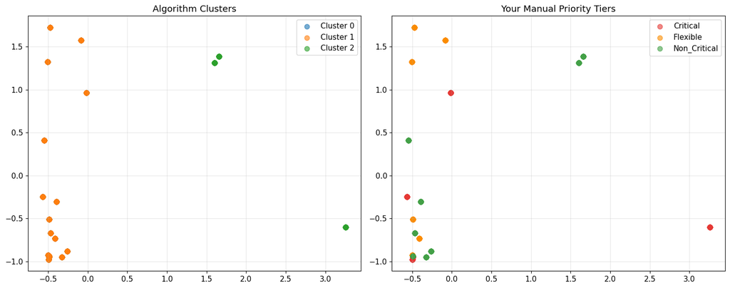

```python
# Extension — Clustering
from sklearn.cluster import KMeans
from sklearn.preprocessing import StandardScaler

# YOUR CODE HERE
# 1. Scale your features (KMeans is sensitive to scale)
scaler = StandardScaler()
X_scaled = scaler.fit_transform(X)
#
# 2. Fit KMeans with k=3
kmeans = KMeans(n_clusters=3, random_state=42, n_init=10)
kmeans.fit(X_scaled)
#
# 3. Compare cluster assignments to your priority labels
#    Look at which building types land in each cluster
df['cluster'] = kmeans.labels_

print('Cluster assignments by building type:')
print(df.groupby(['building_type', 'priority_tier'])['cluster'].first().sort_values())

# 4. Visualize using a scatter plot of two features, colored by cluster
fig, (ax1, ax2) = plt.subplots(1, 2, figsize=(15, 6))

for cluster in range(3):
    mask = kmeans.labels_ == cluster
    ax1.scatter(X_scaled[mask, selected_features.index('global_mean_kWh')],
                X_scaled[mask, selected_features.index('variability_ratio')],
                label=f'Cluster {cluster}', alpha=0.6, s=50)
ax1.set_title('Algorithm Clusters')
ax1.legend()

for tier, color in TIER_COLORS.items():
    mask = df.loc[X.index, 'priority_tier'] == tier
    ax2.scatter(X_scaled[mask, selected_features.index('global_mean_kWh')],
                X_scaled[mask, selected_features.index('variability_ratio')],
                label=tier, alpha=0.6, s=50, color=color)
ax2.set_title('Your Manual Priority Tiers')
ax2.legend()

plt.tight_layout()
plt.show()

# YOUR ANALYSIS: The cluster model was completly unable to create correct groupings based on the priorities.
# The cluster model completly ignored one cluster, and only assigned the three highest energy users to cluster 2.
# When looking at a gragh of the two most important features it is easy to see why this occured, all of the buildings are clustered near the lower end of energy usage, with three outliers to the high end.
# The selections from the human labels apear to be scattered completly randomly, and without the human input thier importance is almost unidentifiable.
```

## What Comes Next

You have now drawn the data, predicted demand with regression, and classified users by priority. The three colors on your palette are mixed.

In Week 4 you will paint the finished picture: an optimization model that distributes finite power across your smart city community — using everything your team has built, debated, and learned.

Your regression predictions tell you how much each building needs. Your classification tiers tell you who gets served first. Your optimization model decides how to make those two things work together when the grid cannot give everyone what they need.

*Quick Start Orange County: AI Design Contest — University of Florida*